# Simulation

Jesse

2019年10月15日

We’ve learnt *Data-visulization*, *summary statistics tables*, *ifelse*, *function*, and *loop*.  
Now it’s time for us to make use of all these techniques to do some advanced works － **Simulation**.

Today, we gonna try one simulation － *dice rolling averages*.

# Dice Rolling Averages

We will simulate dice rolling for 2000 times, and calculate the average points.  
What’s more, we’ll see what might happen as we roll the dice more and more times.

## Step 1 : Dice Rolling.

First of all, we need to try rolling the dice.  
Here, we use `random` and `floor` (or `ceiling`) function to help us create random integers.

*Remember to set.seed() or you will get different rsults every time you run your code*

```r
set.seed(503)
```

After we setting seed, now it’s time to roll the dice.

```r
dice_rolling_2000 <- floor(runif(2000,1,7))  #ceiling(runif(2000,0,6))
```

## Step 2 : Do some statistics summary.

After rolling dices, we could see some statistics summary with function `summary`.

```r
summary(dice_rolling_2000)
```

```
##    Min. 1st Qu.  Median    Mean 3rd Qu.    Max.
##   1.000   2.000   3.000   3.478   5.000   6.000
```

### Question

How to create *mean* and *standard deviation* of *dice_rolling_2000*?

## Step 3 : Calculating average dice roll.

Next, we can start try calulating average dice roll with `for loop`.

```r
#Create an empty vector to store the averages.

average_dice_roll_2000 <- c()

#Create average vector with for loop
dice_sum = 0
for (i in 1:2000) {
  dice_sum = dice_sum + dice_rolling_2000[i]
  average_dice_roll_2000[i] = dice_sum / i
}
```

### Question

How to create average vector with `while loop`?

## Step 4 : Visulize the result.

As we want to see the impact of rolling times getting larger.

```r
average_dice_roll_2000
```

```
##    [1] 4.000000 2.500000 2.333333 2.250000 2.200000 2.500000 3.000000
##    [8] 2.875000 3.000000 3.200000 3.454545 3.666667 3.615385 3.714286
##   [15] 3.866667 3.750000 3.647059 3.777778 3.736842 3.850000 3.809524
##   [22] 3.909091 3.869565 3.791667 3.760000 3.653846 3.740741 3.714286
##   [29] 3.655172 3.600000 3.580645 3.531250 3.575758 3.588235 3.628571
##   [36] 3.583333 3.567568 3.526316 3.487179 3.500000 3.560976 3.500000
##   [43] 3.511628 3.522727 3.577778 3.521739 3.553191 3.562500 3.612245
##   [50] 3.600000 3.607843 3.576923 3.622642 3.592593 3.581818 3.553571
##   [57] 3.543860 3.500000 3.457627 3.433333 3.393443 3.403226 3.412698
##   [64] 3.406250 3.384615 3.424242 3.402985 3.382353 3.391304 3.428571
##   [71] 3.422535 3.458333 3.438356 3.445946 3.426667 3.407895 3.415584
##   [78] 3.410256 3.405063 3.437500 3.407407 3.426829 3.445783 3.416667
##   [85] 3.447059 3.465116 3.482759 3.511364 3.494382 3.500000 3.483516
##   [92] 3.500000 3.483871 3.510638 3.536842 3.531250 3.546392 3.530612
##   [99] 3.555556 3.560000 3.534653 3.509804 3.485437 3.480769 3.466667
```

[output cut: 271 more lines]

We can’t get much information from numbers.  
With plot, we might know them more!

Here know, we gonna create a plot with `geom_line`.(Remember to `library(tidyverse)`)

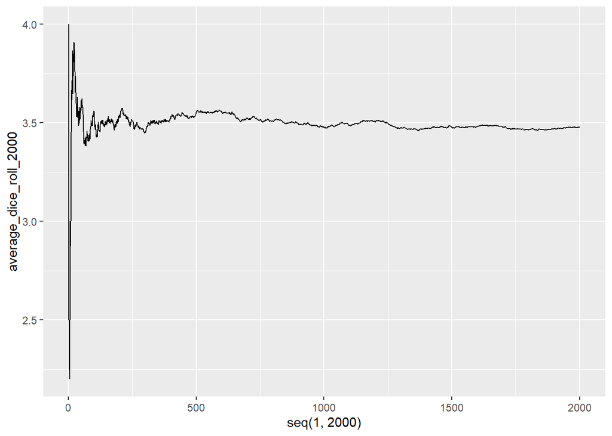

```r
ggplot() +
  geom_line(mapping = aes(x=seq(1,2000), y=average_dice_roll_2000))
```

With plots, we could see as rolling times geting bigger, the average’s more close to 3.5!

### Question

While we know more about average_dice_roll, we could also know more about dice rolling sequence(dice_rolling_2000) through create histogram of it. Try make one!

## Review: ifelse

`if else` are really important functions and we might use them a lot. Therefore, let’s do some review and try coding with them.

*Qeustion: how many numbers bigger than 3 are there in dice_rolling_2000*

Method 1

```r
bigger_than_3 = 0
for (i in 1:2000) {
  if(dice_rolling_2000[i] > 3)
  {
    bigger_than_3 = bigger_than_3 + 1
  }
}
bigger_than_3
```

```
## [1] 978
```

Method 2

```r
# Method 2
bigger_than_3_sequecne = ifelse(dice_rolling_2000 > 3, 1 , 0)
bigger_than_3 = sum(bigger_than_3_sequecne)

bigger_than_3
```

```
## [1] 978
```

### Question

Calculate the counts of numbers being 5 or 6, numbers being 3 or 4, numbers being 1 or 2 in dice_rolling_2000.  
Hint: Use `if` `else if` `else`.

## Final : Make simulation a function.

After we conducting our simulations, we might want to make all these into a function.  
Next time we want to implement the same or similar simulation, we can directly call the function.

```r
dice_rolling_simulation <- function()
{
  dice_rolling_2000 <- floor(runif(2000,1,7))
  average_dice_roll_2000 <- c()
  dice_sum = 0
  for (i in 1:2000) {
    dice_sum = dice_sum + dice_rolling_2000[i]
    average_dice_roll_2000[i] = dice_sum / i
    }
  ggplot() +
    geom_line(mapping = aes(x=seq(1,2000), y=average_dice_roll_2000))
}
```

And next time we want to implement the average simulation, we could just call the function.

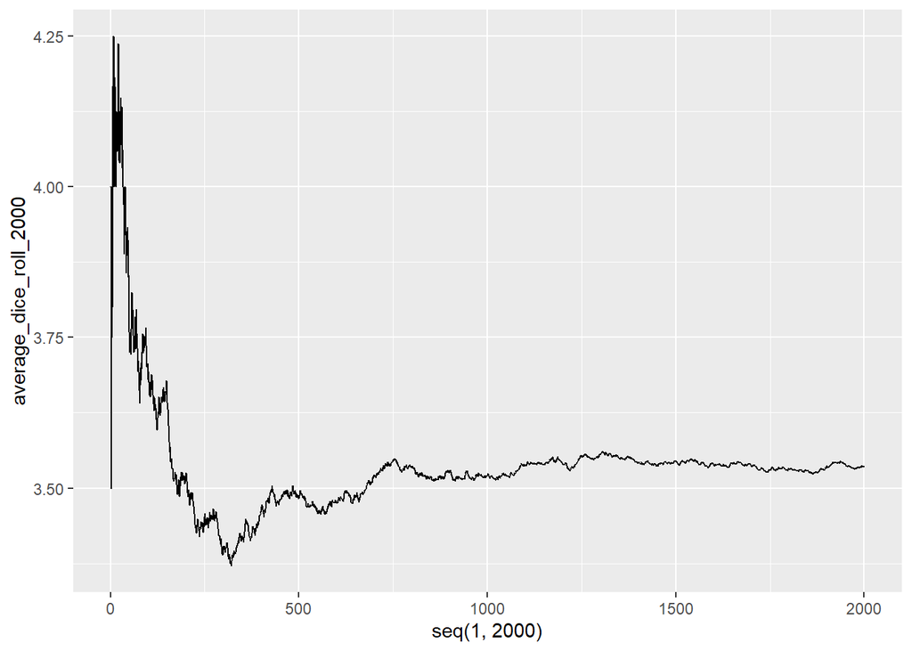

```r
dice_rolling_simulation()
```

Nevertheless, as might want to do some adjustments toward our function, We would use **arguments** to make it.  
Like this time, we want to adjust maximum and minimum number for every time we call the function.

```r
dice_rolling_simulation_minmax_adjusted <- function(min, max)
{
  dice_rolling_2000 <- floor(runif(2000,min,max + 1))
  average_dice_roll_2000 <- c()
  dice_sum = 0
  for (i in 1:2000) {
    dice_sum = dice_sum + dice_rolling_2000[i]
    average_dice_roll_2000[i] = dice_sum / i
    }
  ggplot() +
    geom_line(mapping = aes(x=seq(1,2000), y=average_dice_roll_2000))
}
```

And next time, if we want to conduct similar simulations but maxmium being 8, we can call the function.

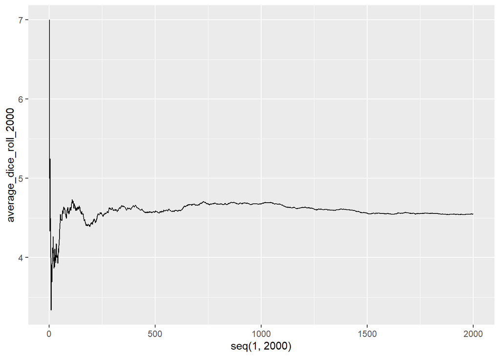

```r
dice_rolling_simulation_minmax_adjusted(min = 1, max = 8)
```

```r
dice_rolling_simulation_minmax_adjusted <- function(min = 1, max = 6)
{
  dice_rolling_2000 <- floor(runif(2000,min,max + 1))
  average_dice_roll_2000 <- c()
  dice_sum = 0
  for (i in 1:2000) {
    dice_sum = dice_sum + dice_rolling_2000[i]
    average_dice_roll_2000[i] = dice_sum / i
    }
  ggplot() +
    geom_line(mapping = aes(x=seq(1,2000), y=average_dice_roll_2000))
}
```

### Question

Create a function where dice rolling times being adjustable.  
If possible, set default rolling times to be 2000.